# Ramanujan’s Mock Theta Functions

In the final months of his life (1919–1920), Ramanujan wrote letters to G. H. Hardy describing a new type of function he called **"Mock Theta Functions"**.

He listed 17 examples, but without formal definitions.  
These mysterious functions seemed similar to the classical theta functions of modular form theory — yet they did **not** behave exactly like modular forms.

For decades, mathematicians puzzled over what “mock” meant, until **Sander Zwegers (2002)** showed that Ramanujan’s mock theta functions are related to **harmonic Maass forms** — completing a century-old mystery.

### A Simple Example

One of Ramanujan’s third-order mock theta functions is:

$$ f(q) = 1 + \sum_{n=1}^{\infty} \frac{q^{n^2}}{(1+q)^2 (1+q^2)^2 \cdots (1+q^n)^2} $$

We can approximate ( f(q) ) numerically for ( |q| < 1 ) and explore how it behaves as ( q \to 1^- ).

```python
import numpy as np
import matplotlib.pyplot as plt
```

```python
def mock_theta_f(q, n_terms=50):
    """
    Compute a truncated approximation of Ramanujan’s third-order mock theta function f(q).
    f(q) = 1 + sum_{n=1}^∞ q^{n^2} / ∏_{k=1}^{n} (1 + q^k)^2
    """
    total = 1.0
    for n in range(1, n_terms + 1):
        numerator = q**(n**2)
        denom = np.prod([(1 + q**k)**2 for k in range(1, n + 1)])
        total += numerator / denom
    return total
```

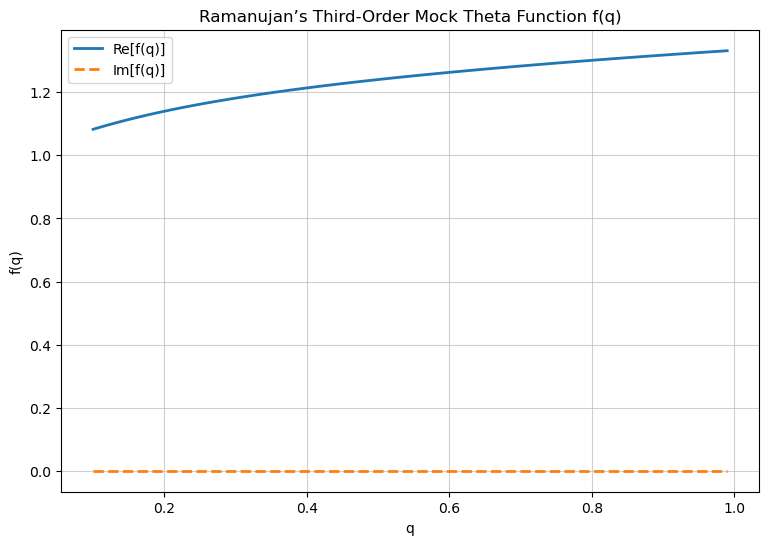

```python
q_values = np.linspace(0.1, 0.99, 50)
f_values = np.array([mock_theta_f(q, n_terms=50) for q in q_values])

plt.figure(figsize=(9,6))
plt.plot(q_values, np.real(f_values), label="Re[f(q)]", linewidth=2)
plt.plot(q_values, np.imag(f_values), '--', label="Im[f(q)]", linewidth=2)
plt.title("Ramanujan’s Third-Order Mock Theta Function f(q)")
plt.xlabel("q")
plt.ylabel("f(q)")
plt.grid(True, alpha=0.6)
plt.legend()
plt.show()
```

### Mathematical Significance

Ramanujan’s mock theta functions are now understood as **holomorphic parts** of **harmonic Maass forms** — functions that generalize modular forms by allowing a non-holomorphic “shadow” term.

In modern notation, a mock theta function ( f(q) ) is paired with a modular form ( g(q) ) such that:

$$ \widehat{f}(q) = f(q) + g^*(q) $$

where ( g^*(q) ) is a non-holomorphic integral transform of ( g(q) ).

These discoveries revealed deep connections between:

- **Number theory**,
- **Modular forms**,
- **String theory**, and
- **Black hole entropy** (via modern physics interpretations of modularity).

Ramanujan anticipated — without formal proof — structures that wouldn’t be fully understood until nearly a **century later**.  
This is perhaps the clearest example of his mathematical intuition operating far ahead of its time.

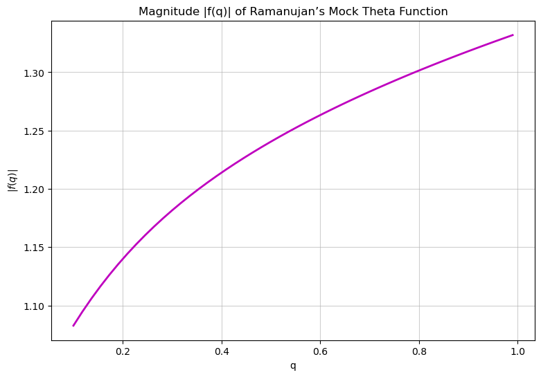

```python
plt.figure(figsize=(9,6))
plt.plot(q_values, np.abs(f_values), 'm-', linewidth=2)
plt.title("Magnitude |f(q)| of Ramanujan’s Mock Theta Function")
plt.xlabel("q")
plt.ylabel(r"$|f(q)|$")
plt.grid(True, alpha=0.6)
plt.show()
```

### Discussion

Ramanujan’s Mock Theta Functions represent the culmination of his mathematical journey.

- They **bridge** the gap between classical modular forms and modern number theory.
- Their structure inspired major breakthroughs in the **Langlands program**, **string theory**, and **quantum modular forms**.
- The rediscovery of their meaning by Zwegers (2002) and subsequent work by Ono and Bringmann confirmed Ramanujan’s **deep foresight**.

### References

- S. Ramanujan, *The Lost Notebook and Other Unpublished Papers* (Springer, 1988).
- G. E. Andrews & B. C. Berndt, *Ramanujan’s Lost Notebook*, Part I–V.
- S. Zwegers, *Mock Theta Functions*, Ph.D. thesis, Utrecht University (2002).
- Ken Ono, *The Web of Modularity*, American Mathematical Society (2004).

> *“It is as though a composer left sketches of symphonies that could only be completed with instruments invented decades later.”*  
> — Adapted from Ken Ono’s reflections on Ramanujan.